# Week Two Milestone Report

HPSUN

2018年1月3日

## Introduction

This report is an exploratory analysis of the datasets. We will using these datasets to build a prediction algorithm apply to a mobile phone app SwiftKey, so that the app will guess what is next word user wants to input. This may save the user lot of time.  
We are using corpora collected from publicly available sources by a web crawler. The corpora are in four languages and each language has three parts from webnews, blog and twitter. For easy analysis, I will only use the English dataset.

## Data download and process

```r
fileUrl = "https://d396qusza40orc.cloudfront.net/dsscapstone/dataset/Coursera-SwiftKey.zip"
if (!file.exists("Coursera-SwiftKey.zip")) {
    download.file(fileUrl,"Coursera-SwiftKey.zip",mode = "wb",method = "auto")
}
#unzip("Coursera-SwiftKey.zip")
Sys.setlocale(category = "LC_ALL", locale = "English_United States.1252")
```

```
## [1] "LC_COLLATE=English_United States.1252;LC_CTYPE=English_United States.1252;LC_MONETARY=English_United States.1252;LC_NUMERIC=C;LC_TIME=English_United States.1252"
```

```r
news_path = ".\\final\\en_US\\en_US.news.txt"
blog_path = ".\\final\\en_US\\en_US.blogs.txt"
twitter_path = ".\\final\\en_US\\en_US.twitter.txt"
```

## Data explore1

```r
library(tokenizers)
library(tidytext)
library(dplyr)
library(tidyr)
library(igraph)
library(ggplot2)
library(ggraph)

len = function(line) {
    length(unlist(tokenize_words(line)))
}
```

### news

```r
news = read.table(news_path,sep="\n",header=F,stringsAsFactors=F,quote = "",encoding = "UTF-8")
words = sapply(as.list(news$V1),len)
nws = sum(words)
nls = length(words)
nwm = mean(words,na.rm = T)
```

### blog

```r
blog = read.table(blog_path,sep="\n",header=F,stringsAsFactors=F,quote = "",encoding = "UTF-8")
words = sapply(as.list(blog$V1),len)
bws = sum(words)
bls = length(words)
bwm = mean(words,na.rm = T)
```

### twitter

```r
twitter = read.table(twitter_path,sep="\n",header=F,stringsAsFactors=F,quote = "",encoding = "UTF-8")
words = sapply(as.list(twitter$V1),len)
tws = sum(words)
tls = length(words)
twm = mean(words,na.rm = T)
```

## Data explore2

Prepare some functions

```r
top_n_grams = function(grams_hist,n) {
    dt = grams_hist[c(1:n),]
    colnames(dt) = c("gram","count")
    dt$gram = factor(dt$gram, levels=dt$gram[n:1])
    title = paste("Top",n,"ngrams",sep=" ")
    ggplot(dt,aes(x = gram, y = count)) +
        geom_col(show.legend = FALSE) + coord_flip() +
        labs(title=title,x="")
}

visualize_bigrams = function(bigrams) {
  set.seed(2018)
  a <- grid::arrow(type = "closed", length = unit(.1, "inches"))
  bigrams %>%
    ggraph(layout = "fr") +
    geom_edge_link(show.legend = FALSE, arrow = a) +
    geom_node_point(color = "lightblue", size = 5) +
    geom_node_text(aes(label = name), vjust = 1, hjust = 1) +
    theme_void() + labs(title="Most common bigrams")
}
```

### news

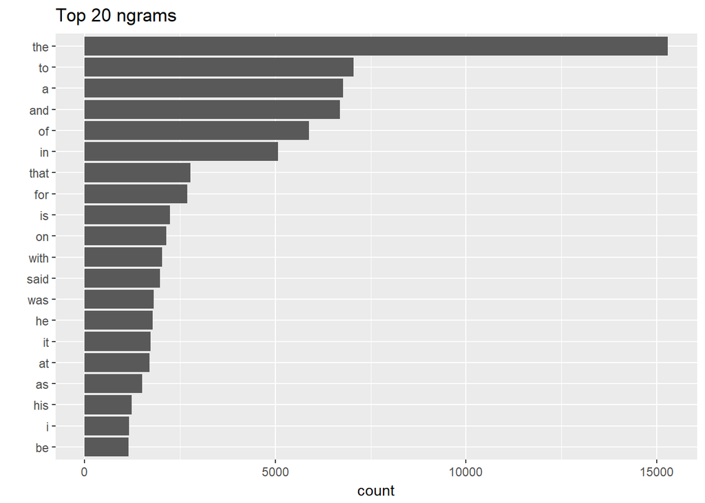

```r
n = nrow(news)
set.seed(2018)
ind = sample(c(1:n),floor(n/10))
news2 = as.data.frame(news[ind,],stringsAsFactors = F)
colnames(news2) = "V1"

news1gram_Hist <- unnest_tokens(news2, unigram, V1, token = "ngrams", n = 1) %>%
    count(unigram, sort = TRUE)
top_n_grams(news1gram_Hist,20)
```

```r
news1gram_Hist$cumprob = cumsum(news1gram_Hist$n)/sum(news1gram_Hist$n)
nuw = nrow(news1gram_Hist)
n50 = which(news1gram_Hist$cumprob > 0.5)[1]
n90 = which(news1gram_Hist$cumprob > 0.9)[1]
print(object.size(news1gram_Hist), units = "auto")
```

```
## 1.8 Mb
```

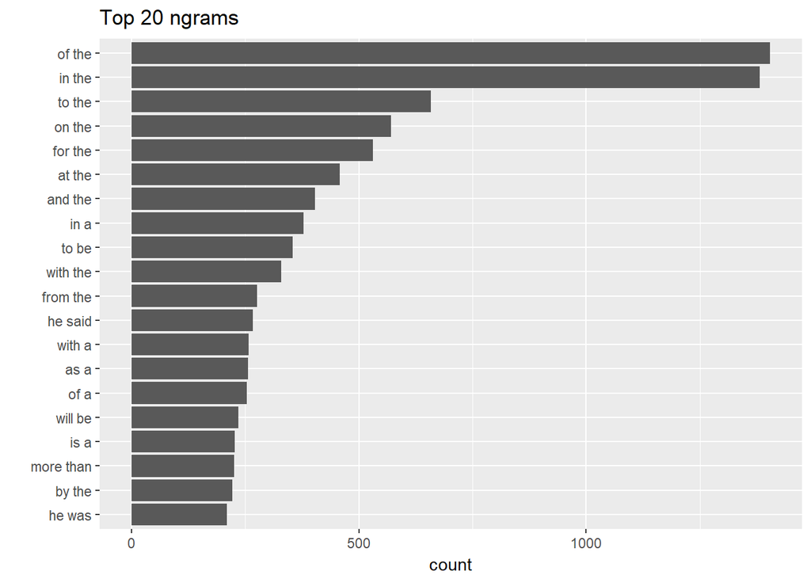

```r
rm(news1gram_Hist)

news2gram_Hist <- unnest_tokens(news2, bigram, V1, token = "ngrams", n = 2) %>%
    count(bigram, sort = TRUE)
top_n_grams(news2gram_Hist,20)
```

```r
print(object.size(news2gram_Hist), units = "auto")
```

```
## 10.9 Mb
```

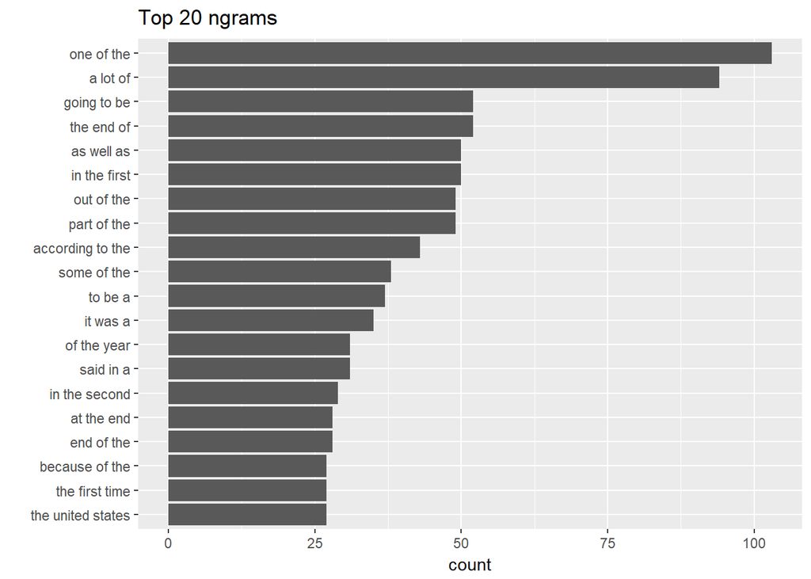

```r
news3gram_Hist <- unnest_tokens(news2, trigram, V1, token = "ngrams", n = 3) %>%
    count(trigram, sort = TRUE)
top_n_grams(news3gram_Hist,20)
```

```r
print(object.size(news3gram_Hist), units = "auto")
```

```
## 18.1 Mb
```

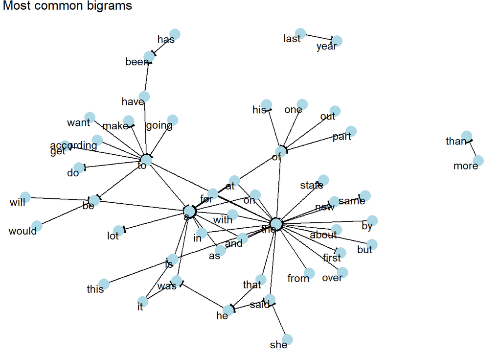

```r
rm(news3gram_Hist)

bigram_graph <- news2gram_Hist %>%
    separate(bigram, c("word1", "word2"), sep = " ") %>%
    filter(n > 100) %>%
    graph_from_data_frame()
visualize_bigrams(bigram_graph)
```

```r
rm(news2gram_Hist,bigram_graph)
```

### blog

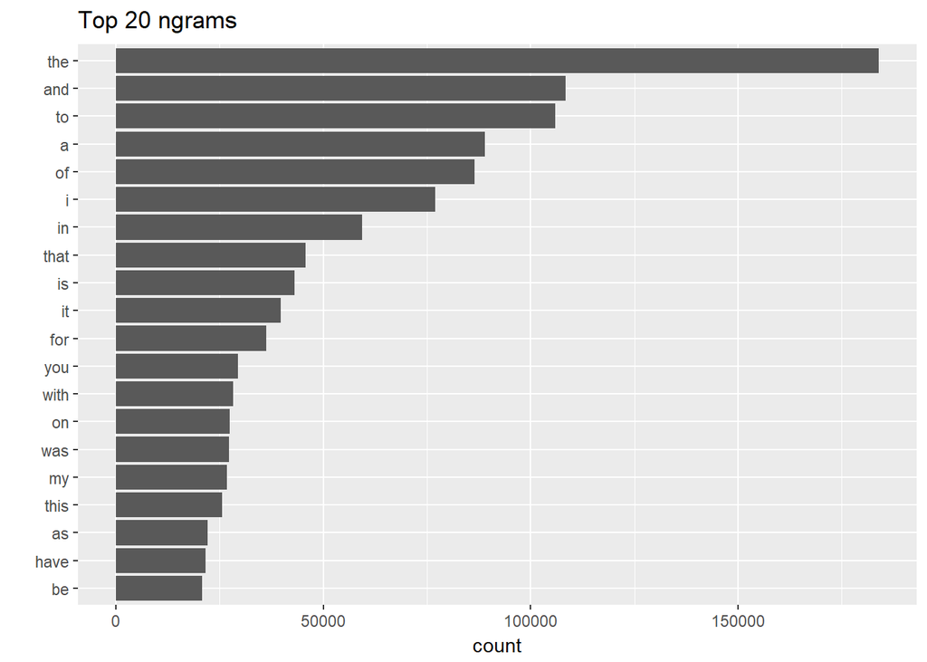

```r
n = nrow(blog)
set.seed(2018)
ind = sample(c(1:n),floor(n/10))
blog2 = as.data.frame(blog[ind,],stringsAsFactors = F)
colnames(blog2) = "V1"

blog1gram_Hist <- unnest_tokens(blog2, unigram, V1, token = "ngrams", n = 1) %>%
    count(unigram, sort = TRUE)
top_n_grams(blog1gram_Hist,20)
```

```r
blog1gram_Hist$cumprob = cumsum(blog1gram_Hist$n)/sum(blog1gram_Hist$n)
buw = nrow(blog1gram_Hist)
b50 = which(blog1gram_Hist$cumprob > 0.5)[1]
b90 = which(blog1gram_Hist$cumprob > 0.9)[1]
print(object.size(blog1gram_Hist), units = "auto")
```

```
## 6.6 Mb
```

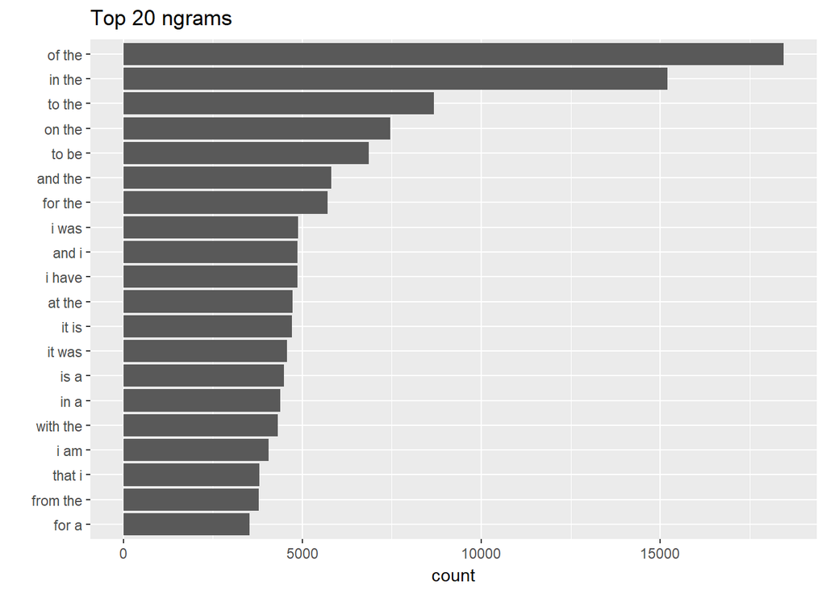

```r
rm(blog1gram_Hist)


blog2gram_Hist <- unnest_tokens(blog2, bigram, V1, token = "ngrams", n = 2) %>%
    count(bigram, sort = TRUE)
top_n_grams(blog2gram_Hist,20)
```

```r
print(object.size(blog2gram_Hist), units = "auto")
```

```
## 81.8 Mb
```

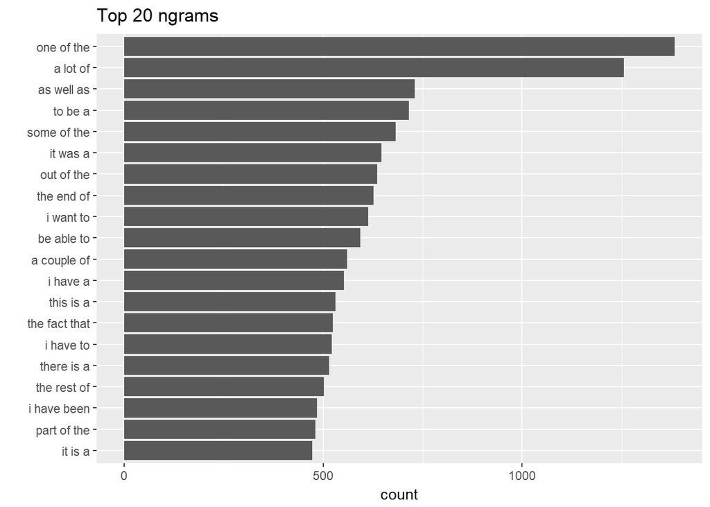

```r
blog3gram_Hist <- unnest_tokens(blog2, trigram, V1, token = "ngrams", n = 3) %>%
    count(trigram, sort = TRUE)
top_n_grams(blog3gram_Hist,20)
```

```r
print(object.size(blog3gram_Hist), units = "auto")
```

```
## 200.2 Mb
```

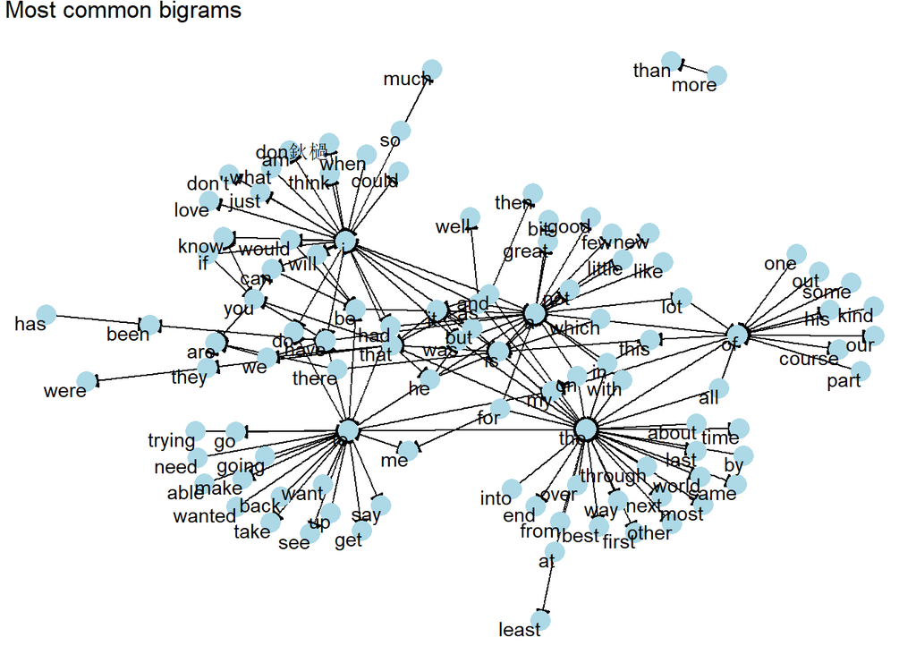

```r
rm(blog3gram_Hist)

bigram_graph <- blog2gram_Hist %>%
    separate(bigram, c("word1", "word2"), sep = " ") %>%
    filter(n > 1000) %>%
    graph_from_data_frame()
visualize_bigrams(bigram_graph)
```

```r
rm(blog2gram_Hist,bigram_graph)
```